# Project: Train a Quadcopter How to Fly

In this project we'll design an agent to fly a quadcopter, and then train it using a reinforcement learning algorithm!

## Structure

Take a look at the files in the directory to better understand the structure of the project.

- `task.py`: Defines the task (environment).
- `agents/`: Folder containing reinforcement learning agents.
  - `policy_search.py`: A sample agent is provided here.
  - `agent.py`: Develop our agent.
- `physics_sim.py`: Contains the simulator for the quadcopter.

For this project, we will define our own task in `task.py`. We will also design a reinforcement learning agent in `agent.py` to complete the chosen task. We will also define a `model.py` file defining needed neural network architectures.

## Controlling the Quadcopter

A sample agent is given in the code cell below to show how to use the sim to control the quadcopter. This agent is even simpler than the sample agent that we'll examine (in `agents/policy_search.py`) later in this notebook!

The agent controls the quadcopter by setting the revolutions per second on each of its four rotors. The provided agent in the `Basic_Agent` class below always selects a random action for each of the four rotors. These four speeds are returned by the `act` method as a list of four floating-point numbers.

For this project, the agent that we will implement in `agents/agent.py` will have a far more intelligent method for selecting actions!

```python
import random

class Basic_Agent():
    def __init__(self, task):
        self.task = task

    def act(self):
        new_thrust = random.gauss(450., 25.)
        return [new_thrust + random.gauss(0., 1.) for x in range(4)]
```

Run the code cell below to have the agent select actions to control the quadcopter.

We can change the provided values of `runtime`, `init_pose`, `init_velocities`, and `init_angle_velocities` below to change the starting conditions of the quadcopter.

The `labels` list below annotates statistics that are saved while running the simulation. All of this information is saved in a text file `data.txt` and stored in the dictionary `results`.

```python
%load_ext autoreload
%autoreload 2

import csv
import numpy as np
from task import Task

# Modify the values below to give the quadcopter a different starting position.
runtime = 5.                                     # time limit of the episode
init_pose = np.array([0., 0., 10., 0., 0., 0.])  # initial pose
init_velocities = np.array([0., 0., 0.])         # initial velocities
init_angle_velocities = np.array([0., 0., 0.])   # initial angle velocities
file_output = 'data.txt'                         # file name for saved results

# Setup
task = Task(init_pose, init_velocities, init_angle_velocities, runtime)
agent = Basic_Agent(task)
done = False
labels = ['time', 'x', 'y', 'z', 'phi', 'theta', 'psi', 'x_velocity',
          'y_velocity', 'z_velocity', 'phi_velocity', 'theta_velocity',
          'psi_velocity', 'rotor_speed1', 'rotor_speed2', 'rotor_speed3', 'rotor_speed4']
results = {x : [] for x in labels}

# Run the simulation, and save the results.
with open(file_output, 'w') as csvfile:
    writer = csv.writer(csvfile)
    writer.writerow(labels)
    while True:
        rotor_speeds = agent.act()
        _, _, done = task.step(rotor_speeds)
        to_write = [task.sim.time] + list(task.sim.pose) + list(task.sim.v) + list(task.sim.angular_v) + list(rotor_speeds)
        for ii in range(len(labels)):
            results[labels[ii]].append(to_write[ii])
        writer.writerow(to_write)
        if done:
            break
```

Run the code cell below to visualize how the position of the quadcopter evolved during the simulation.

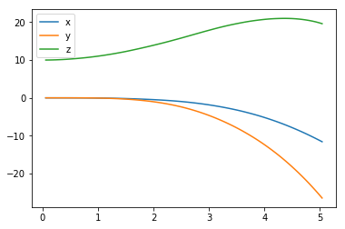

```python
import matplotlib.pyplot as plt
%matplotlib inline

plt.plot(results['time'], results['x'], label='x')
plt.plot(results['time'], results['y'], label='y')
plt.plot(results['time'], results['z'], label='z')
plt.legend()
_ = plt.ylim()
```

The next code cell visualizes the velocity of the quadcopter.

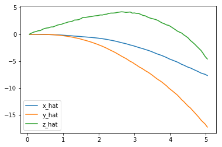

```python
plt.plot(results['time'], results['x_velocity'], label='x_hat')
plt.plot(results['time'], results['y_velocity'], label='y_hat')
plt.plot(results['time'], results['z_velocity'], label='z_hat')
plt.legend()
_ = plt.ylim()
```

Next, we plot the Euler angles (the rotation of the quadcopter over the $x$-, $y$-, and $z$-axes),

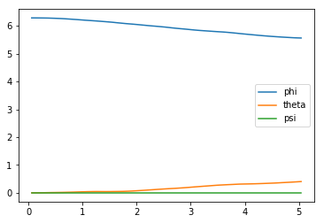

```python
plt.plot(results['time'], results['phi'], label='phi')
plt.plot(results['time'], results['theta'], label='theta')
plt.plot(results['time'], results['psi'], label='psi')
plt.legend()
_ = plt.ylim()
```

before plotting the velocities (in radians per second) corresponding to each of the Euler angles.

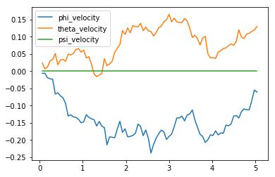

```python
plt.plot(results['time'], results['phi_velocity'], label='phi_velocity')
plt.plot(results['time'], results['theta_velocity'], label='theta_velocity')
plt.plot(results['time'], results['psi_velocity'], label='psi_velocity')
plt.legend()
_ = plt.ylim()
```

Finally, we print the agent's choice of actions.

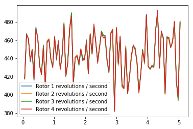

```python
plt.plot(results['time'], results['rotor_speed1'], label='Rotor 1 revolutions / second')
plt.plot(results['time'], results['rotor_speed2'], label='Rotor 2 revolutions / second')
plt.plot(results['time'], results['rotor_speed3'], label='Rotor 3 revolutions / second')
plt.plot(results['time'], results['rotor_speed4'], label='Rotor 4 revolutions / second')
plt.legend()
_ = plt.ylim()
```

When specifying a task, we will derive the environment state from the simulator. Run the code cell below to print the values of the following variables at the end of the simulation:

- `task.sim.pose` (the position of the quadcopter in ($x,y,z$) dimensions and the Euler angles),
- `task.sim.v` (the velocity of the quadcopter in ($x,y,z$) dimensions), and
- `task.sim.angular_v` (radians/second for each of the three Euler angles).

```python
# the pose, velocity, and angular velocity of the quadcopter at the end of the episode
print(task.sim.pose)
print(task.sim.v)
print(task.sim.angular_v)
```

```
[-11.60595312 -26.49431062  19.61843088   5.56148666   0.40529104   0.        ]
[ -7.70018773 -17.33221304  -4.60909735]
[-0.06058716  0.13022269  0.        ]
```

In the sample task in `task.py`, a 6-dimensional pose of the quadcopter is used to construct the state of the environment at each timestep. However, when amending the task for our purposes, we can expand the size of the state vector by including the velocity information. We can use any combination of the pose, velocity, and angular velocity to construct the state to suit our task.

## The Task

A sample task is shown in `task.py`.

The `__init__()` method is used to initialize several variables that are needed to specify the task.

- The simulator is initialized as an instance of the `PhysicsSim` class (from `physics_sim.py`).
- Inspired by the methodology in the original DDPG paper, action repeats are used. For each timestep of the agent, we step the simulation `action_repeats` timesteps. More can be read about action repeats in the **Results** section of [the DDPG paper](https://arxiv.org/abs/1509.02971).
- We set the number of elements in the state vector. For the sample task, we only work with the 6-dimensional pose information. To set the size of the state (`state_size`), we must take action repeats into account.
- The environment will always have a 4-dimensional action space, with one entry for each rotor (`action_size=4`). We can set the minimum (`action_low`) and maximum (`action_high`) values of each entry here.
- The sample task in this provided file is for the agent to reach a target position. We specify that target position as a variable.

The `reset()` method resets the simulator. The agent should call this method every time the episode ends. We can see an example of this in the code cell below.

The `step()` method is perhaps the most important. It accepts the agent's choice of action `rotor_speeds`, which is used to prepare the next state to pass on to the agent. Then, the reward is computed from `get_reward()`. The episode is considered done if the time limit has been exceeded, or the quadcopter has travelled outside of the bounds of the simulation.

In the next section, we will test the performance of an agent on this task.

## The Agent

In the sample agent in `agents/policy_search.py` we use a very simplistic linear policy to directly compute the action vector as a dot product of the state vector and a matrix of weights. Then, it randomly perturbs the parameters by adding some Gaussian noise, to produce a different policy. Based on the average reward obtained in each episode (`score`), it keeps track of the best set of parameters found so far, how the score is changing, and accordingly tweaks a scaling factor to widen or tighten the noise.

Run the code cell below to see how the agent performs on the sample task.

```python
import sys
import pandas as pd
from agents.policy_search import PolicySearch_Agent
from task import Task

num_episodes = 1000
target_pos = np.array([0., 0., 10.])
task = Task(target_pos=target_pos)
agent = PolicySearch_Agent(task)

for i_episode in range(1, num_episodes+1):
    state = agent.reset_episode() # start a new episode
    while True:
        action = agent.act(state)
        next_state, reward, done = task.step(action)
        agent.step(reward, done)
        state = next_state
        if done:
            print("\rEpisode = {:4d}, score = {:7.3f} (best = {:7.3f}), noise_scale = {}".format(
                i_episode, agent.score, agent.best_score, agent.noise_scale), end="")  # [debug]
            break
    sys.stdout.flush()
```

```
Episode = 1000, score =  -3.880 (best =   0.056), noise_scale = 3.2555
```

This agent should perform very poorly on this task. And that's where we start!

## Define the Task, Design the Agent, and Train the Agent!

We'll amend `task.py` to specify a task of our choosing. The common tasks to specify could be: teaching our quadcopter to takeoff, hovering in place, landing softly, or reaching a target pose. After specifying a task, we use the sample agent in `agents/policy_search.py` as a template to define our own agent in `agents/agent.py`.

Note that it is **highly unlikely** that the first agent and task that we specify will learn well. We will likely have to tweak various hyperparameters and the reward function for our task until we arrive at reasonably good behavior.

As we develop our agent, it's important to keep an eye on how it's performing. We'll build in a mechanism to log/save the total rewards obtained in each episode to file. If the episode rewards are gradually increasing, this is an indication that our agent is learning.

```python
## Train your agent here.
import sys
import csv
import numpy as np
import pandas as pd
from task import Task
from agents.agent import DDPG

# Take-off task

# Initial pose for landing
runtime = 5.
init_pose = np.array([0., 0., 0., 0., 0., 0.])
init_velocities = np.array([0., 0., 0.])
init_angle_velocities = np.array([0., 0., 0.])
file_output = 'rewards.txt'
episodes = 1000
target_pos = np.array([0., 0., 10.])
done = False

# Setup in case of DDPG agent
task = Task(target_pos = target_pos)
agent = DDPG(task)
labels = ['episode', 'rewards_total']
results = {x : [] for x in labels}

# Running sim and saving results.
with open(file_output, 'w') as csvfile:
    writer = csv.writer(csvfile)
    writer.writerow(labels)
    best_total_reward = 0
    for i in range(1, episodes+1):
        state = agent.reset_episode()
        total_reward = 0
        while True:
            action = agent.act(state)
            next_state, reward, done = task.step(action)
            total_reward += reward
            if total_reward > best_total_reward:
                best_total_reward = total_reward
            agent.step(action, reward, next_state, done)
            state = next_state
            if done:
                to_write = [i] + [total_reward]
                for ii in range(len(labels)):
                    results[labels[ii]].append(to_write[ii])
                writer.writerow(to_write)
                print("\rEpisode = {:4d}, total_reward = {:7.3f} (best = {:7.3f})".format(
                    i, total_reward, best_total_reward), end="")
                break
        sys.stdout.flush()
```

```
Episode = 1000, total_reward =  20.253 (best =  53.858))
```

## Plot the Rewards

Once we are satisfied with the performance, we'll plot the episode rewards, either from a single run, or averaged over multiple runs.

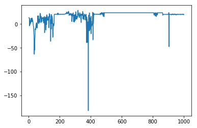

```python
## Plot the rewards.
import matplotlib.pyplot as plt
%matplotlib inline

plt.plot(results['episode'], results['rewards_total'])
plt.legend()
_ = plt.ylim()
```

## Reflections

Describe the task that we specified in `task.py`. How did we design the reward function?

I trained my agent for Take off task. I modified the reward function to `1. - .2*(abs(self.sim.pose[:3] - self.target_pos)).sum()` and set it to stay between -1 and +1.

Discuss our agent briefly:

- What learning algorithm(s) did we try? What worked best for us?
- What was the final choice of hyperparameters (such as $\alpha$, $\gamma$, $\epsilon$, etc.)?
- What neural network architecture did we use (if any)? Specify layers, sizes, activation functions, etc.

I used a Neural network with different layers.

**Neural network architecture for actor class:**

State:

Dense(hidden_units = 32, regularizer_l2 = 0.01, activity_regularizer = 0.01) Batch_normalization() Activation(relu) Dropout(keep_prob = 0.5)

Dense(hidden_units = 64, regularizer_l2 = 0.01, activity_regularizer = 0.01) Batch_normalization() Activation(relu) Dropout(keep_prob = 0.5)

Dense(hidden_units = 128, regularizer_l2 = 0.01, activity_regularizer = 0.01) Batch_normalization() Activation(relu) Dropout(keep_prob = 0.5)

Dense(hidden_units = 64, regularizer_l2 = 0.01, activity_regularizer = 0.01) Batch_normalization() Activation(relu) Dropout(keep_prob = 0.5)

Dense(hidden_units = action_size, activation = sigmoid)

**Neural Network architecture for Critic class:**

State:

Dense(hidden_units = 32, regularizer_l2 = 0.01, activity_regularizer = 0.01) Batch_normalization() Activation(relu) Dropout(keep_prob = 0.5)

Dense(hidden_units = 64, regularizer_l2 = 0.01, activity_regularizer = 0.01) Batch_normalization() Activation(relu) Dropout(keep_prob = 0.5)

Dense(hidden_units = 128, regularizer_l2 = 0.01, activity_regularizer = 0.01) Batch_normalization() Activation(relu) Dropout(keep_prob = 0.5)

Action:

Dense(hidden_units = 64, regularizer_l2 = 0.01, activity_regularizer = 0.01) Batch_normalization() Activation(relu) Dropout(keep_prob = 0.5)

Dense(hidden_units = 64, regularizer_l2 = 0.01, activity_regularizer = 0.01) Batch_normalization() Activation(relu) Dropout(keep_prob = 0.5)

Dense(hidden_units = 128, regularizer_l2 = 0.01, activity_regularizer = 0.01) Batch_normalization() Activation(relu) Dropout(keep_prob = 0.5)

Finally, I combined action and state and applied a dense layer with relu activation

Looking at the episode rewards plot, how did the agent learn over time?

- Was it an easy task to learn or hard?
- Was there a gradual learning curve, or an aha moment?
- How good was the final performance of the agent? (e.g. mean rewards over the last 10 episodes)

It was not an easy task, since the training took a lot of time and I wasn't sure if the agent was learning properly. The final performance, as you can see from the plot, is relatively stable.

Analysis of the project:

- What was the hardest part of the project? (e.g. getting started, plotting, specifying the task, etc.)
- Did we find anything interesting in how the quadcopter or the agent behaved?

The hardest part obviously was figuring out everything and getting started. Tweaking the layers of the neural network architecture for the actor and critic classes, and training the agent took a lot of time.